# Creating Data

Benjamin Egan

#### Created 4/3/25

## Objective

As I mentioned in piece 3, I serve as a teaching assistant for the undergraduate Research Methods in psychology course at Wake Forest University. They are required to write a final paper, for which they need to write up and analyze a 2x2 experiment. As a TA, I have to create the data for the experiment. Since it’s a 2x2 between subjects with at least 100 participants, this would be incredibly difficult. Luckily I walked through module 13 on simulating data, and should be able to create the data.

The basic function I’ll need to use is rnorm(). This will let me randomly generate a sample of a normal distribution. I’m starting and making sure I can actually generate the data.

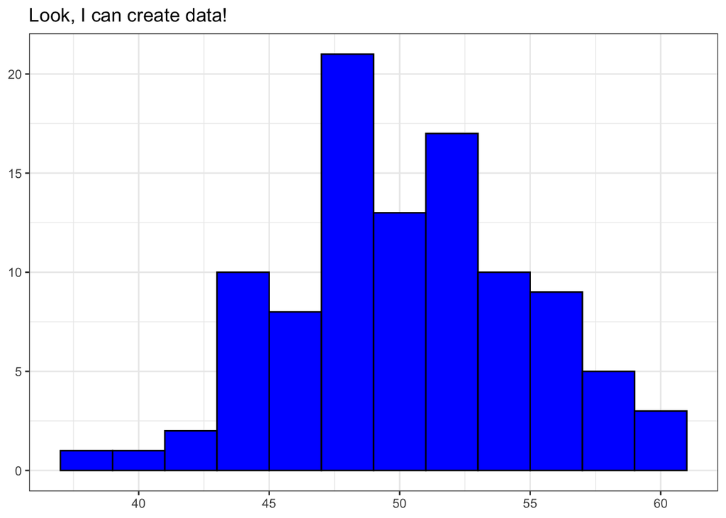

```r
set.seed(123)

base_rnorm <- rnorm(100, mean = 50, sd = 5)

first_attempt <- data.frame(id = 1:100, base_rnorm)


data.frame(first_attempt) %>%
ggplot(
 aes(x=base_rnorm)
)+
  theme_bw()+
  geom_histogram(binwidth=2,color="black", fill="blue") +
  labs(
    title = "Look, I can create data!",
    x = NULL,
    y = NULL
    )
```

My plan is to create four different samples, one for each group. I then will join them to create a large dataset. This way I can control the main effects and interactions.

The experiment calls for two variables, Sugar (sugar/no sugar) and Caffeine (caffeine/no caffeine), and the DV is reported distance to an object.

I also included gender and age for students to be able to use in their participants sections.

## Creating the groups

### Sugar and caffeine

```r
set.seed(101)

Distance <- rnorm(30, mean = 235, sd = 23.03)

Gender <- c("Male","Female")
Gender <- sample(Gender, 30, replace=TRUE, prob=c(0.5, 0.5))

Age <- rnorm(30, mean = 19, sd = .5)

group1 <- data.frame(id = 1:30, Gender, round(Age,0), Sugar = 1, Caffeine = 1, round(Distance,0))
```

Using round() allowed me to make distance a whole number

### No Sugar and no caffeine

```r
set.seed(102)

Distance <- rnorm(30, mean = 275, sd = 20.1)

Gender <- c("Male","Female")
Gender <- sample(Gender, 30, replace=TRUE, prob=c(0.5, 0.5))

Age <- rnorm(30, mean = 19, sd = .5)

group2 <- data.frame(id = 31:60, Gender, round(Age,0), Sugar = 0, Caffeine = 0, round(Distance,0))
```

### Sugar and no caffeine

```r
set.seed(103)

Distance <- rnorm(30, mean = 282, sd = 21.3)

Gender <- c("Male","Female")
Gender <- sample(Gender, 30, replace=TRUE, prob=c(0.5, 0.5))

Age <- rnorm(30, mean = 19, sd = .5)

group3 <- data.frame(id = 61:90, Gender, round(Age,0), Sugar = 1, Caffeine = 0, round(Distance,0))
```

### No sugar and caffeine

```r
set.seed(104)

Distance <- rnorm(30, mean = 250, sd = 23.05)

Gender <- c("Male","Female")
Gender <- sample(Gender, 30, replace=TRUE, prob=c(0.5, 0.5))

Age <- rnorm(30, mean = 19, sd = .5)

group4 <- data.frame(id = 91:120, Gender, round(Age,0), Sugar = 0, Caffeine = 1, round(Distance,0))
```

## Joining the groups

Here I join the datasets together. I only know how to join two datasets at once, so I decided to join the all/none together. I also renamed the distance and age variables, and saved the dataset.

```r
group1and2 <- group1 %>% full_join(group2)
```

[output not shown]

```r
group3and4 <- group3 %>% full_join(group4)
```

[output not shown]

```r
lab_12_data <- group1and2 %>% full_join(group3and4)
```

[output not shown]

```r
lab_12_data <- lab_12_data %>%
  rename(Distance = round.Distance..0.)

lab_12_data <- lab_12_data %>%
  rename(Age = round.Age..0.)

write_sav(lab_12_data, "class_data_official.sav")

Test_data <- read_sav("class_data_official.sav")
```

lab_12_data is a data frame that includes an ID number, if they had sugar or caffeine, and a distance score.

## Testing my dataset

I want to make sure there is a main effect of caffeine, no main effect of sugar, and an interaction that suggests the influence of both caffeine and sugar highly reduces perceived distance. Here, I ran a factorial ANOVA on the data and plotted the means

This top one is my attempt, which 100% works

```r
Visual <- Test_data %>%
  mutate(Sugar = case_when(
    Sugar == 0 ~ "No Sugar",
    Sugar == 1 ~ "Sugar"
  ))

Visual <- Visual %>%
  mutate(Caffeine = case_when(
    Caffeine == 0 ~ "No Caffeine",
    Caffeine == 1 ~ "Caffeine"
  ))

aov(Distance ~ Sugar * Caffeine, Visual) %>%
summary()
```

```
##                 Df Sum Sq Mean Sq F value Pr(>F)
## Sugar            1   1274    1274   3.148 0.0786 .
## Caffeine         1  47960   47960 118.514 <2e-16 ***
## Sugar:Caffeine   1   2075    2075   5.128 0.0254 *
## Residuals      116  46943     405
## ---
## Signif. codes:  0 '***' 0.001 '**' 0.01 '*' 0.05 '.' 0.1 ' ' 1
```

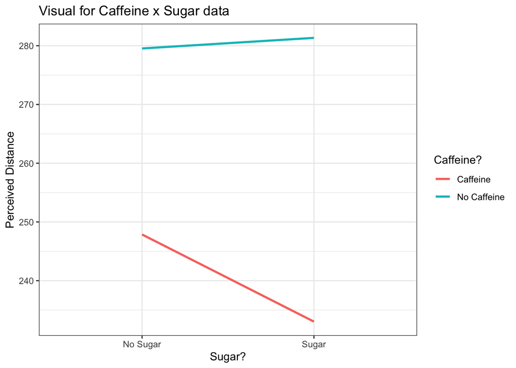

```r
Visual %>%
  ggplot(aes(
    x = Sugar,
    y = Distance,
    group = Caffeine,
    color = Caffeine
  ))+
  geom_smooth(method = lm, se = FALSE)+
  theme_bw()+
  labs(
    x = "Sugar?",
    y = "Perceived Distance",
    color = "Caffeine?",
    title = "Visual for Caffeine x Sugar data"
  )
```

Based on the ANOVA and the graph, it looks like I accomplished my goal.

This is a more streamlined version created by ChatGPT. I was looking to make a version for a classmate who had minimal experience in r. I knew they’d change the means and standard deviations, and wanted to make sure the change was reflected on the graph.

```r
aov(Distance ~ Sugar * Caffeine, Visual) %>%
summary()
```

```
##                 Df Sum Sq Mean Sq F value Pr(>F)
## Sugar            1   1274    1274   3.148 0.0786 .
## Caffeine         1  47960   47960 118.514 <2e-16 ***
## Sugar:Caffeine   1   2075    2075   5.128 0.0254 *
## Residuals      116  46943     405
## ---
## Signif. codes:  0 '***' 0.001 '**' 0.01 '*' 0.05 '.' 0.1 ' ' 1
```

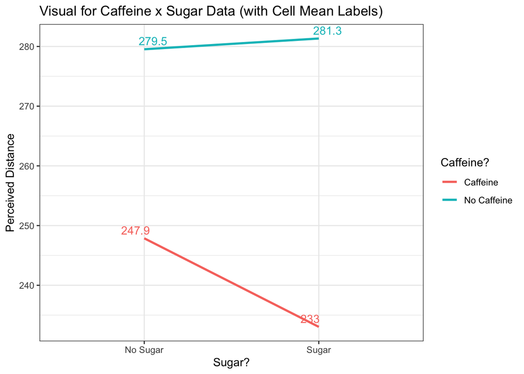

```r
    # Step 1: Create labeled version of your raw data
Visual1 <- Test_data %>%
  mutate(
    Sugar = case_when(Sugar == 0 ~ "No Sugar", Sugar == 1 ~ "Sugar"),
    Caffeine = case_when(Caffeine == 0 ~ "No Caffeine", Caffeine == 1 ~ "Caffeine")
  )

# Step 2: Create a data frame of cell means
cell_means1 <- Visual1 %>%
  group_by(Sugar, Caffeine) %>%
  summarise(
    Distance = mean(Distance),
    .groups = "drop"
  )

# Step 3: Plot with trend lines and cell mean *labels*
Visual1 %>%
  ggplot(aes(
    x = Sugar,
    y = Distance,
    group = Caffeine,
    color = Caffeine
  )) +
  geom_smooth(method = lm, se = FALSE) +
  geom_text(
    data = cell_means1,
    aes(label = round(Distance, 1)),  # round to 1 decimal
    position = position_dodge(width = 0.2),
    vjust = -0.5,
    show.legend = FALSE
  ) +
  theme_bw() +
  labs(
    x = "Sugar?",
    y = "Perceived Distance",
    color = "Caffeine?",
    title = "Visual for Caffeine x Sugar Data (with Cell Mean Labels)"
  )
```